# Retail Sales Profit Analysis

```python
import pandas as pd
```

```python
df=pd.read_csv('Retail_SalesMarketing_ProfitCost.csv')
```

```python
df.shape
```

```
(84672, 16)
```

```python
df.head()
```

|  | Year | Product line | Product type | Product | Order method type | Retailer country | Revenue | Planned revenue | Product cost | Quantity | Unit cost | Unit price | Gross profit | Unit sale price | Unnamed: 14 | Unnamed: 15 |
| --- | --- | --- | --- | --- | --- | --- | --- | --- | --- | --- | --- | --- | --- | --- | --- | --- |
| 0 | 2015 | Camping Equipment | Cooking Gear | TrailChef Water Bag | Telephone | United States | 315,044 | 437,477 | 158,372 | 66,385 | 3.0 | 7 | 156,673 | 5 | NaN | NaN |
| 1 | 2015 | Camping Equipment | Cooking Gear | TrailChef Water Bag | Telephone | Canada | 13,445 | 14,313 | 6,299 | 2,172 | 3.0 | 7 | 7,146 | 6 | NaN | NaN |
| 2 | 2015 | Camping Equipment | Cooking Gear | TrailChef Water Bag | Telephone | Mexico | NaN | NaN | NaN | NaN | NaN | NaN | NaN | NaN | NaN | NaN |
| 3 | 2015 | Camping Equipment | Cooking Gear | TrailChef Water Bag | Telephone | Brazil | NaN | NaN | NaN | NaN | NaN | NaN | NaN | NaN | NaN | NaN |
| 4 | 2015 | Camping Equipment | Cooking Gear | TrailChef Water Bag | Telephone | Japan | 181,120 | 235,237 | 89,413 | 35,696 | 3.0 | 7 | 91,707 | 5 | NaN | NaN |

```python
df.drop(columns=['Unnamed: 14', 'Unnamed: 15'] ,inplace=True)
```

```python
df.columns
```

```
Index(['Year', 'Product line', 'Product type', 'Product', 'Order method type',
       'Retailer country', ' Revenue ', ' Planned revenue ', ' Product cost ',
       ' Quantity ', ' Unit cost ', ' Unit price ', ' Gross profit ',
       ' Unit sale price '],
      dtype='object')
```

### Problem: Examine whether or not the retail store outdoor products are growing, maturing or declining. Compare your prospects for future sales with past performance by analyzing the industry average.

## Data Cleaning

### Lets clean up the data !!

Let's remove the spaces from the column names to remove ambiguity and better efficiency using strip function

```python
df.columns = [cl.strip() for cl in df.columns.tolist()]

df.columns= df.columns.str.replace(' ','_')
df.columns.tolist()
```

```
['Year',
 'Product_line',
 'Product_type',
 'Product',
 'Order_method_type',
 'Retailer_country',
 'Revenue',
 'Planned_revenue',
 'Product_cost',
 'Quantity',
 'Unit_cost',
 'Unit_price',
 'Gross_profit',
 'Unit_sale_price']
```

```python
df.dtypes
```

```
Year                   int64
Product_line          object
Product_type          object
Product               object
Order_method_type     object
Retailer_country      object
Revenue               object
Planned_revenue       object
Product_cost          object
Quantity              object
Unit_cost            float64
Unit_price            object
Gross_profit          object
Unit_sale_price       object
dtype: object
```

Since we have , in between 315,044 etc, it takes it as an object...so let us remove the commas

```python
df.replace(',','', regex=True, inplace=True)
```

```python
df.head(3)
```

|  | Year | Product_line | Product_type | Product | Order_method_type | Retailer_country | Revenue | Planned_revenue | Product_cost | Quantity | Unit_cost | Unit_price | Gross_profit | Unit_sale_price |
| --- | --- | --- | --- | --- | --- | --- | --- | --- | --- | --- | --- | --- | --- | --- |
| 0 | 2015 | Camping Equipment | Cooking Gear | TrailChef Water Bag | Telephone | United States | 315044 | 437477 | 158372 | 66385 | 3.0 | 7 | 156673 | 5 |
| 1 | 2015 | Camping Equipment | Cooking Gear | TrailChef Water Bag | Telephone | Canada | 13445 | 14313 | 6299 | 2172 | 3.0 | 7 | 7146 | 6 |
| 2 | 2015 | Camping Equipment | Cooking Gear | TrailChef Water Bag | Telephone | Mexico | NaN | NaN | NaN | NaN | NaN | NaN | NaN | NaN |

```python
# df.columns=df.columns.str.replace(' ','')
```

In Pandas missing data is represented by two value:

- None: None is a Python singleton object that is often used for missing data in Python code.
- NaN : NaN (an acronym for Not a Number), is a special floating-point value recognized by all systems that use the standard IEEE floating-point representation (NaN is numpy type)

We find using isnull() and not notnull()

```python
null_series=df.isnull().sum()
# type(null_df)
null_series
```

```
Year                     0
Product_line             0
Product_type             0
Product                  0
Order_method_type        0
Retailer_country         0
Revenue              59929
Planned_revenue      59929
Product_cost         59929
Quantity             59929
Unit_cost            59929
Unit_price           59929
Gross_profit         59929
Unit_sale_price      59929
dtype: int64
```

These are the null/missing values in the dataset

```python
notnull_series=df.notnull().sum()
# type(notnull_df)
notnull_series
```

```
Year                 84672
Product_line         84672
Product_type         84672
Product              84672
Order_method_type    84672
Retailer_country     84672
Revenue              24743
Planned_revenue      24743
Product_cost         24743
Quantity             24743
Unit_cost            24743
Unit_price           24743
Gross_profit         24743
Unit_sale_price      24743
dtype: int64
```

These are the values that are Not-Null. Let us combine the null and not null to find percentage of missing values in each column

We are concatenating two series null & not null ,into a dataframe vertically (columns) by setting axis =1 and naming them . Missing_df.columns[list] we are assigning the names

```python
missing_df=pd.concat([null_series,notnull_series], axis=1).reset_index()
missing_df.columns=['Column_name','Null_count','Not_Null_Count']
```

```python
missing_df['Total_count']= missing_df['Null_count'] + missing_df['Not_Null_Count']

missing_df['Missing_values_percent']= (missing_df['Null_count']/ missing_df['Total_count']) *100
missing_df
# Null_count/ (Null_count+Not_Null_Count)* 100
```

|  | Column_name | Null_count | Not_Null_Count | Total_count | Missing_values_percent |
| --- | --- | --- | --- | --- | --- |
| 0 | Year | 0 | 84672 | 84672 | 0.000000 |
| 1 | Product_line | 0 | 84672 | 84672 | 0.000000 |
| 2 | Product_type | 0 | 84672 | 84672 | 0.000000 |
| 3 | Product | 0 | 84672 | 84672 | 0.000000 |
| 4 | Order_method_type | 0 | 84672 | 84672 | 0.000000 |
| 5 | Retailer_country | 0 | 84672 | 84672 | 0.000000 |
| 6 | Revenue | 59929 | 24743 | 84672 | 70.777825 |
| 7 | Planned_revenue | 59929 | 24743 | 84672 | 70.777825 |
| 8 | Product_cost | 59929 | 24743 | 84672 | 70.777825 |
| 9 | Quantity | 59929 | 24743 | 84672 | 70.777825 |
| 10 | Unit_cost | 59929 | 24743 | 84672 | 70.777825 |
| 11 | Unit_price | 59929 | 24743 | 84672 | 70.777825 |
| 12 | Gross_profit | 59929 | 24743 | 84672 | 70.777825 |
| 13 | Unit_sale_price | 59929 | 24743 | 84672 | 70.777825 |

We can find that we have a 70% missing data from column 6 to column 13...which is a lot. We have to eventually delete the data,but lets see which subgroup has maximum no. of missing values

```python
df.groupby(['Product_line'])['Revenue','Year'].count()
```

| Product_line | Revenue | Year |
| --- | --- | --- |
| Camping Equipment | 8375 | 24108 |
| Golf Equipment | 2763 | 8820 |
| Mountaineering Equipment | 2947 | 12348 |
| Outdoor Protection | 2944 | 8820 |
| Personal Accessories | 7714 | 30576 |

We can see that the null count is distributed across all the prroduct lines, (we narrowed down to check if a particular sub-granular group like product line had lots of missing data wrt only one). We can proceed with deleting them.

There was a **70%** data loss happening across all metrics which cannot be manipulated by filling values using **Fillna**.

```python
df=df.dropna()
```

```python
df.head(3)
```

|  | Year | Product_line | Product_type | Product | Order_method_type | Retailer_country | Revenue | Planned_revenue | Product_cost | Quantity | Unit_cost | Unit_price | Gross_profit | Unit_sale_price |
| --- | --- | --- | --- | --- | --- | --- | --- | --- | --- | --- | --- | --- | --- | --- |
| 0 | 2015 | Camping Equipment | Cooking Gear | TrailChef Water Bag | Telephone | United States | 315044 | 437477 | 158372 | 66385 | 3.0 | 7 | 156673 | 5 |
| 1 | 2015 | Camping Equipment | Cooking Gear | TrailChef Water Bag | Telephone | Canada | 13445 | 14313 | 6299 | 2172 | 3.0 | 7 | 7146 | 6 |
| 4 | 2015 | Camping Equipment | Cooking Gear | TrailChef Water Bag | Telephone | Japan | 181120 | 235237 | 89413 | 35696 | 3.0 | 7 | 91707 | 5 |

```python
df.reset_index(drop= True, inplace=True)

# Drop= true as we dont want to carry forward that index. Index was 0,1,4
```

```python
df.head(3)
```

|  | Year | Product_line | Product_type | Product | Order_method_type | Retailer_country | Revenue | Planned_revenue | Product_cost | Quantity | Unit_cost | Unit_price | Gross_profit | Unit_sale_price |
| --- | --- | --- | --- | --- | --- | --- | --- | --- | --- | --- | --- | --- | --- | --- |
| 0 | 2015 | Camping Equipment | Cooking Gear | TrailChef Water Bag | Telephone | United States | 315044 | 437477 | 158372 | 66385 | 3.0 | 7 | 156673 | 5 |
| 1 | 2015 | Camping Equipment | Cooking Gear | TrailChef Water Bag | Telephone | Canada | 13445 | 14313 | 6299 | 2172 | 3.0 | 7 | 7146 | 6 |
| 2 | 2015 | Camping Equipment | Cooking Gear | TrailChef Water Bag | Telephone | Japan | 181120 | 235237 | 89413 | 35696 | 3.0 | 7 | 91707 | 5 |

```python
df.shape
```

[output not shown]

```python
df.dtypes
```

```
Year                   int64
Product_line          object
Product_type          object
Product               object
Order_method_type     object
Retailer_country      object
Revenue               object
Planned_revenue       object
Product_cost          object
Quantity              object
Unit_cost            float64
Unit_price            object
Gross_profit          object
Unit_sale_price       object
dtype: object
```

Let us strip extra spaces, - and such noises in the columns...

```python
df=df.assign(Revenue= df['Revenue'].str.strip(),
             Planned_revenue= df['Planned_revenue'].str.strip(),
             Product_cost= df['Product_cost'].str.strip(),
             Quantity= df['Quantity'].str.strip(),
             Unit_price= df['Unit_price'].str.strip(),
             Gross_profit= df['Gross_profit'].str.strip(),
             Unit_sale_price= df['Unit_sale_price'].str.strip()
            )
# df.iloc[100]
# df['Revenue'].iloc[100]
```

```python
df=df.assign(Revenue= df['Revenue'].str.replace('-',''),
             Planned_revenue= df['Planned_revenue'].str.replace('-',''),
             Product_cost= df['Product_cost'].str.replace('-',''),
             Quantity= df['Quantity'].str.replace('-',''),
             Unit_price= df['Unit_price'].str.replace('-',''),
             Gross_profit= df['Gross_profit'].str.replace('-',''),
             Unit_sale_price= df['Unit_sale_price'].str.replace('-','')
            )
```

Converting to numeric types....

```python
df= df.assign(
    Revenue= pd.to_numeric(df['Revenue']),
    Planned_revenue= pd.to_numeric(df['Planned_revenue']),
    Product_cost= pd.to_numeric(df['Product_cost']),
    Quantity= pd.to_numeric(df['Quantity']),
    Unit_price= pd.to_numeric(df['Unit_price']),
#     Gross_profit= pd.to_numeric(df['Gross_profit']),
    Unit_sale_price= pd.to_numeric(df['Unit_sale_price'])
)
```

```python
df.Gross_profit.iloc[301]
```

```
'(1119)'
```

Since it has paranthesis in place for negative values, lets convert them and change data type

```python
df['Gross_profit']= (df['Gross_profit'].replace( '[\$,)]','', regex=True )
               .replace( '[(]','-',   regex=True ).astype(float))
```

```python
df.dtypes
```

[output not shown]

```python
df.isnull().sum()
```

```
Year                  0
Product_line          0
Product_type          0
Product               0
Order_method_type     0
Retailer_country      0
Revenue              76
Planned_revenue       0
Product_cost          0
Quantity              0
Unit_cost             0
Unit_price            0
Gross_profit          0
Unit_sale_price      76
dtype: int64
```

Revenue and Unit sale price still have 76 null values...lets fill them with 0 as they are not missing. They have no revenue and no sale price

```python
df=df.fillna(0)
```

```python
df.isnull().sum()
```

```
Year                 0
Product_line         0
Product_type         0
Product              0
Order_method_type    0
Retailer_country     0
Revenue              0
Planned_revenue      0
Product_cost         0
Quantity             0
Unit_cost            0
Unit_price           0
Gross_profit         0
Unit_sale_price      0
dtype: int64
```

### The entire data set is cleaned...let us do the exploratory analysis

## Exploratory Analysis

- Summary statistics
- Distribution of Records across product lines
- Distribution of data across countries
- Feature selection Conducting correlation to find which is the best parameter that contri butees to sales profits/ highest revenue

```python
# Summary statistics

df.describe()
```

|  | Year | Revenue | Planned_revenue | Product_cost | Quantity | Unit_cost | Unit_price | Gross_profit | Unit_sale_price |
| --- | --- | --- | --- | --- | --- | --- | --- | --- | --- |
| count | 24743.000000 | 2.474300e+04 | 2.474300e+04 | 2.474300e+04 | 24743.000000 | 24743.000000 | 24743.000000 | 2.474300e+04 | 24743.000000 |
| mean | 2016.345067 | 1.894183e+05 | 1.988176e+05 | 1.116252e+05 | 3606.559067 | 84.946530 | 156.056541 | 7.779312e+04 | 147.254900 |
| std | 1.073106 | 3.907509e+05 | 4.025355e+05 | 2.384156e+05 | 8777.721091 | 131.108962 | 246.805361 | 1.581223e+05 | 232.045043 |
| min | 2015.000000 | 0.000000e+00 | 1.600000e+01 | 6.000000e+00 | 1.000000 | 1.000000 | 2.000000 | -1.816000e+04 | 0.000000 |
| 25% | 2015.000000 | 1.857900e+04 | 1.955700e+04 | 9.431500e+03 | 328.000000 | 11.000000 | 23.000000 | 8.333000e+03 | 20.000000 |
| 50% | 2016.000000 | 5.986700e+04 | 6.390700e+04 | 3.278400e+04 | 1043.000000 | 37.000000 | 67.000000 | 2.579400e+04 | 63.000000 |
| 75% | 2017.000000 | 1.901930e+05 | 2.039955e+05 | 1.113710e+05 | 3288.000000 | 80.000000 | 148.000000 | 7.825400e+04 | 141.000000 |
| max | 2018.000000 | 1.005429e+07 | 1.005429e+07 | 6.756853e+06 | 313628.000000 | 690.000000 | 1360.000000 | 3.521098e+06 | 1308.000000 |

Revenue over the years

```python
import matplotlib.pyplot as plt
def group_analysis(column_name):
    # Generate the results based on the given column_name
    results= df.groupby(column_name).sum()
    results['Revenue_missed_pct'] = ((results['Planned_revenue']-results['Revenue'])/(results['Planned_revenue']))*100.0

    # Then plot the KPI (Key Performance Indicies) for the considered column_name
    fig, axs = plt.subplots(2, 2, figsize=(15,15))
    axs[0,0].bar(results.index,results['Revenue'])
    axs[0,0].set_title('Revenue')
    fig.autofmt_xdate()

    axs[0,1].bar(results.index,results['Planned_revenue'])
    axs[0,1].set_title('Planned_revenue')
    fig.autofmt_xdate()

    axs[1,0].bar(results.index,results['Product_cost'])
    axs[1,0].set_title('Product_cost')
    fig.autofmt_xdate()

    axs[1,1].bar(results.index,results['Gross_profit'])
    axs[1,1].set_title('Gross_profit')
    fig.autofmt_xdate()

#     Plot for missed revenue and the column name
    results.plot.barh(y='Revenue_missed_pct')
    plt.ylabel=('Revenue_missed_pct')
    plt.xlabel=(results.index)

    #     ax = results.plot.barh(x='Revenue_missed_pct', y=results.index)
    return results
```

| Year | Revenue | Planned_revenue | Product_cost | Quantity | Unit_cost | Unit_price | Gross_profit | Unit_sale_price | Revenue_missed_pct |
| --- | --- | --- | --- | --- | --- | --- | --- | --- | --- |
| 2015 | 9.143529e+08 | 968475273 | 546735041 | 20174730 | 605714.0 | 1115154 | 367617948.0 | 1042079.0 | 5.588411 |
| 2016 | 1.159196e+09 | 1218177535 | 690512038 | 23524685 | 605797.0 | 1092246 | 468683778.0 | 1031078.0 | 4.841811 |
| 2017 | 1.495891e+09 | 1560738939 | 872630604 | 25941790 | 495691.0 | 921617 | 623260635.0 | 877109.0 | 4.154940 |
| 2018 | 1.117336e+09 | 1171950964 | 652063489 | 19595886 | 394630.0 | 732290 | 465272886.0 | 693262.0 | 4.660142 |

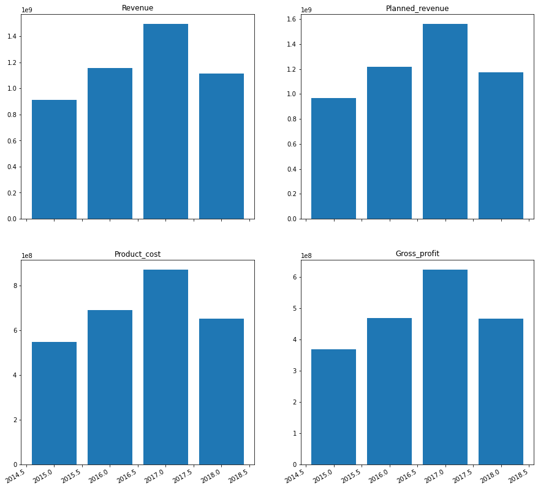

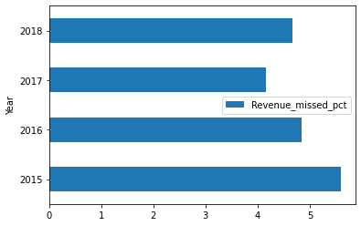

```python
group_analysis('Year')
```

| Product_line | Year | Revenue | Planned_revenue | Product_cost | Quantity | Unit_cost | Unit_price | Gross_profit | Unit_sale_price | Revenue_missed_pct |
| --- | --- | --- | --- | --- | --- | --- | --- | --- | --- | --- |
| Camping Equipment | 16886376 | 1.589037e+09 | 1703124790 | 1002237787 | 27301149 | 754776.0 | 1268118 | 586799155.0 | 1191877.0 | 6.698751 |
| Golf Equipment | 5571060 | 7.264114e+08 | 790261053 | 374217745 | 5113701 | 693534.0 | 1419337 | 352193680.0 | 1322223.0 | 8.079568 |
| Mountaineering Equipment | 5943678 | 4.096602e+08 | 430568075 | 246384239 | 9900091 | 185392.0 | 302861 | 163275949.0 | 287501.0 | 4.855878 |
| Outdoor Protection | 5935833 | 7.599434e+07 | 80005280 | 30011034 | 12014445 | 10472.0 | 25602 | 45983327.0 | 24348.0 | 5.013339 |
| Personal Accessories | 15553479 | 1.885673e+09 | 1915383513 | 1109090367 | 34907705 | 457658.0 | 845389 | 776583136.0 | 817579.0 | 1.551127 |

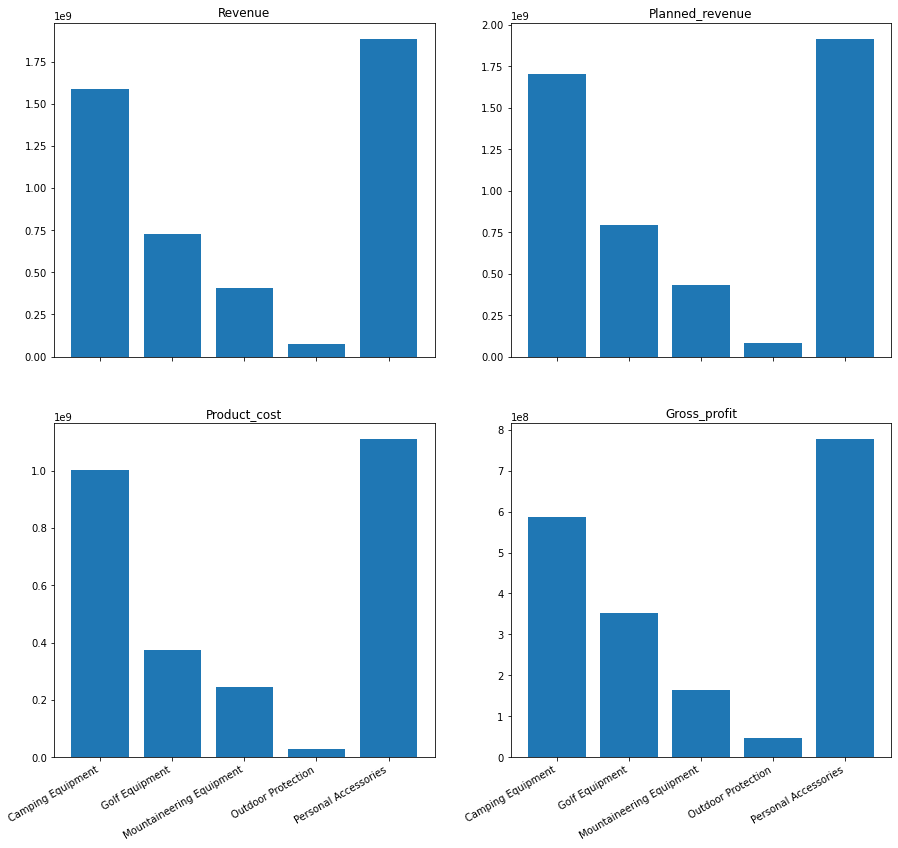

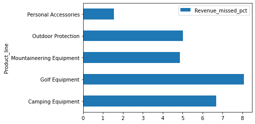

```python
group_analysis('Product_line')
```

| Retailer_country | Year | Revenue | Planned_revenue | Product_cost | Quantity | Unit_cost | Unit_price | Gross_profit | Unit_sale_price | Revenue_missed_pct |
| --- | --- | --- | --- | --- | --- | --- | --- | --- | --- | --- |
| Australia | 1857486 | 109299974.0 | 115311829 | 64254527 | 2000781 | 76472.0 | 139500 | 45045456.0 | 132200.0 | 5.213563 |
| Austria | 2240195 | 143709418.0 | 149549365 | 84147249 | 2742824 | 95182.0 | 174512 | 59562183.0 | 164684.0 | 3.905030 |
| Belgium | 1951807 | 113031619.0 | 118195712 | 66372307 | 2124791 | 75948.0 | 138325 | 46659336.0 | 131558.0 | 4.369104 |
| Brazil | 1504085 | 138276680.0 | 144697428 | 81387153 | 2591989 | 65678.0 | 120706 | 56889537.0 | 114105.0 | 4.437362 |
| Canada | 3441944 | 306159372.0 | 319653077 | 180416413 | 5722733 | 138890.0 | 252253 | 125742997.0 | 239257.0 | 4.221359 |
| China | 1842903 | 317244917.0 | 334082002 | 187417612 | 6110945 | 89506.0 | 166923 | 129827307.0 | 157188.0 | 5.039806 |
| Denmark | 1602886 | 62013037.0 | 64526127 | 36803620 | 1301136 | 58199.0 | 104951 | 25209421.0 | 99282.0 | 3.894686 |
| Finland | 1669339 | 188575323.0 | 198950287 | 111502578 | 3603492 | 66496.0 | 120998 | 77072755.0 | 113849.0 | 5.214852 |
| France | 3211876 | 286569519.0 | 300166336 | 168780985 | 5529613 | 135531.0 | 249099 | 117788568.0 | 234453.0 | 4.529761 |
| Germany | 3302882 | 262313078.0 | 275476051 | 154658565 | 5084611 | 136106.0 | 249054 | 107654509.0 | 234939.0 | 4.778264 |
| Italy | 2514362 | 186648117.0 | 196181889 | 109579819 | 3545695 | 104284.0 | 192412 | 77068308.0 | 181504.0 | 4.859660 |
| Japan | 3365197 | 357446635.0 | 374437913 | 210315931 | 6787127 | 147334.0 | 273881 | 147130706.0 | 258109.0 | 4.537809 |
| Korea | 2074717 | 200725320.0 | 212939596 | 118797376 | 3902092 | 90867.0 | 167671 | 81927974.0 | 157702.0 | 5.736029 |
| Mexico | 2165367 | 167187026.0 | 177346704 | 98849705 | 3175752 | 91625.0 | 168281 | 68337351.0 | 158549.0 | 5.728710 |
| Netherlands | 2435565 | 184321687.0 | 193917160 | 108704507 | 3448760 | 104459.0 | 192132 | 75617204.0 | 180166.0 | 4.948233 |
| Singapore | 2381155 | 197622402.0 | 208460742 | 116855753 | 3788595 | 100989.0 | 186702 | 80766665.0 | 175607.0 | 5.199224 |
| Spain | 2312759 | 165066493.0 | 173636549 | 96906541 | 3171715 | 100201.0 | 186009 | 68159942.0 | 175661.0 | 4.935629 |
| Sweden | 2093248 | 95411467.0 | 99623254 | 56122289 | 1681811 | 87679.0 | 159907 | 39289182.0 | 151123.0 | 4.227715 |
| Switzerland | 1623527 | 100731878.0 | 104890676 | 58855881 | 1822191 | 73297.0 | 137480 | 41876018.0 | 130090.0 | 3.964888 |
| United Kingdom | 2419810 | 277509546.0 | 291298415 | 163835204 | 5378361 | 101947.0 | 185999 | 113674387.0 | 175439.0 | 4.733589 |
| United States | 3879316 | 826912620.0 | 866001599 | 487377157 | 15722077 | 161142.0 | 294512 | 339535441.0 | 278063.0 | 4.513731 |

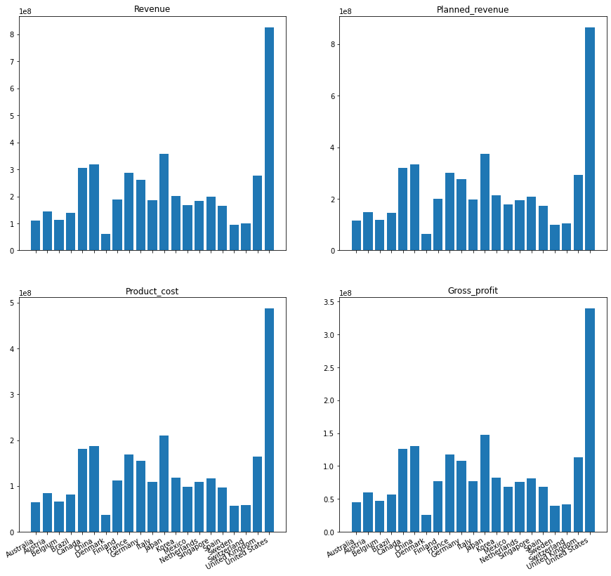

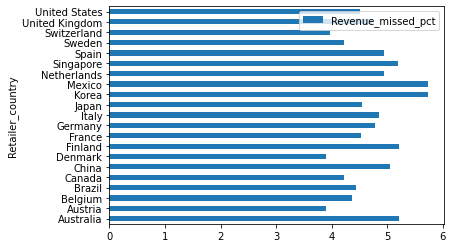

```python
group_analysis('Retailer_country')
```

- Which country had highest number of sales?
- Which product sold the most and. which product line had more revenue loss?

```python
df.head(3)
```

|  | Year | Product_line | Product_type | Product | Order_method_type | Retailer_country | Revenue | Planned_revenue | Product_cost | Quantity | Unit_cost | Unit_price | Gross_profit | Unit_sale_price |
| --- | --- | --- | --- | --- | --- | --- | --- | --- | --- | --- | --- | --- | --- | --- |
| 0 | 2015 | Camping Equipment | Cooking Gear | TrailChef Water Bag | Telephone | United States | 315044.0 | 437477 | 158372 | 66385 | 3.0 | 7 | 156673.0 | 5.0 |
| 1 | 2015 | Camping Equipment | Cooking Gear | TrailChef Water Bag | Telephone | Canada | 13445.0 | 14313 | 6299 | 2172 | 3.0 | 7 | 7146.0 | 6.0 |
| 2 | 2015 | Camping Equipment | Cooking Gear | TrailChef Water Bag | Telephone | Japan | 181120.0 | 235237 | 89413 | 35696 | 3.0 | 7 | 91707.0 | 5.0 |

## Feature selection

Feature selection huggely impacts performance of model. It :

- reduces overfitting
  - improves accuracy
  - reduces training time

There are 3 methods of feature selection:

- Univariate selection
- Feature importance
- Correlation matrix with Heatmap

```python
# Adding more features

df['Missed_Revenue']=df['Planned_revenue']-df['Revenue']
df['revenue_to_cost_rate']=(df['Revenue']/df['Product_cost'])
```

```python
df['revenue_to_cost_rate'].head(3)
```

```
0    1.989266
1    2.134466
2    2.025656
Name: revenue_to_cost_rate, dtype: float64
```

#### 'revenue_to_cost_rate' of 1.989266 can be interpreted as - if you spend $1, you can yield a revenue of $1.989266. The more.. the better..

```python
# Univariate selection

import numpy as np
from sklearn.feature_selection import SelectKBest
from sklearn.feature_selection import chi2


x = df.iloc[:,6:10]  #independent columns
y = df.iloc[:,-2]    #target column i.e Gross_profit

#apply SelectKBest class to extract top 10 best features
bestfeatures = SelectKBest(score_func=chi2, k='all')
fit = bestfeatures.fit(x,y)
dfscores = pd.DataFrame(fit.scores_)
dfcolumns = pd.DataFrame(x.columns)

#concat two dataframes for better visualization
featureScores = pd.concat([dfcolumns,dfscores],axis=1)

featureScores.columns = ['Feature_Name','Score']  #naming the dataframe columns
print(featureScores.nlargest(10,'Score'))  #print 10 best features
```

```
      Feature_Name         Score
1  Planned_revenue  1.131347e+10
0          Revenue  1.065375e+10
2     Product_cost  7.025373e+09
3         Quantity  2.488430e+08
```

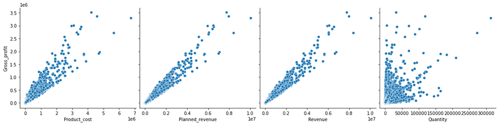

```python
# Let's see how Gross Profit is related with other variables using scatter plot.
import seaborn as sns
sns.pairplot(df, x_vars=['Product_cost', 'Planned_revenue', 'Revenue', 'Quantity'],
             y_vars='Gross_profit', height=4, aspect=1, kind='scatter')
plt.show()
```

#### Top three features that are selected by the algorithm does not have any outliers. However Quantity is not a linearly increasing metrics with Gross_Profit

We can ignore considering **Quantity** for the model, since we are taking the overall Revenue and Cost for determining the profits and not Unit_Cost or Unit_Sale

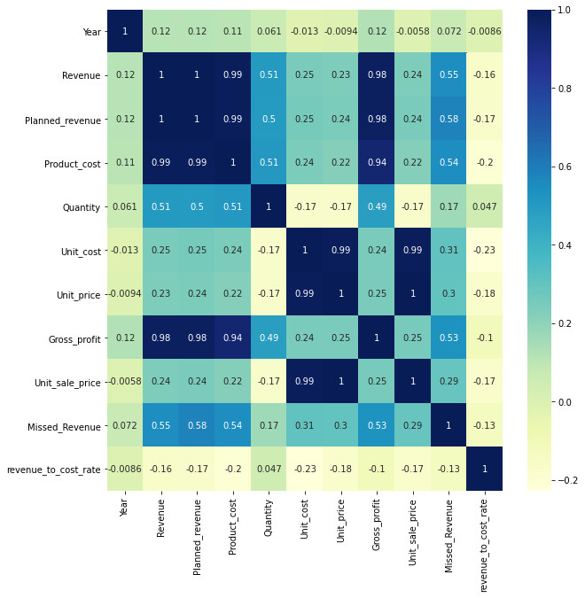

```python
# Let's see the correlation between different variables.

fig, ax = plt.subplots(figsize=(10,10))
sns.heatmap(df.corr(), cmap="YlGnBu", annot = True, ax=ax)
plt.show()
```

This further proves that Revenue, Planned Revenue and Product Cost are the best and most correlated metrics to grossprofit

## Predictive models

- Partition the data into 80% training and 20% validation.
- Explain how using validation set helps to avoid overfitting/underfitting
- At least build two models using decision tree, logistic regression, linear regression, neural network, and knn.
- Assess, analyze, and compare the performance of your models

### Model 1: Multi-Variable Regression

```python
X = df[['Revenue','Planned_revenue','Product_cost']]
y = df['Gross_profit']
```

```python
from sklearn.model_selection import train_test_split
X_train, X_test, y_train, y_test = train_test_split(X, y, train_size = 0.8, test_size = 0.2, random_state = 100)
```

```python
X_train.head()
```

|  | Revenue | Planned_revenue | Product_cost |
| --- | --- | --- | --- |
| 13586 | 71571.0 | 73497 | 31013 |
| 14657 | 186462.0 | 196276 | 132296 |
| 2130 | 33813.0 | 35219 | 23594 |
| 23741 | 0.0 | 2840 | 1318 |
| 2486 | 13409.0 | 13822 | 8931 |

```python
print(X_train.shape)
print(X_test.shape)
print(y_train.shape)
print(y_test.shape)
```

```
(19794, 3)
(4949, 3)
(19794,)
(4949,)
```

```python
import statsmodels.api as sm

# Add a constant to get an intercept
X_train_sm = sm.add_constant(X_train)

# Fit the resgression line using 'OLS'
lr = sm.OLS(y_train, X_train_sm).fit()
```

```python
lr.params
```

```
const              1.355763e-02
Revenue            9.999998e-01
Planned_revenue    6.130563e-08
Product_cost      -9.999999e-01
dtype: float64
```

```python
# Performing a summary operation lists out all the different parameters of the regression line fitted
print(lr.summary())
```

```
                            OLS Regression Results
==============================================================================
Dep. Variable:           Gross_profit   R-squared:                       1.000
Model:                            OLS   Adj. R-squared:                  1.000
Method:                 Least Squares   F-statistic:                 9.382e+14
Date:                Tue, 10 Aug 2021   Prob (F-statistic):               0.00
Time:                        23:10:53   Log-Likelihood:                -10872.
No. Observations:               19794   AIC:                         2.175e+04
Df Residuals:                   19790   BIC:                         2.178e+04
Df Model:                           3
Covariance Type:            nonrobust
===================================================================================
                      coef    std err          t      P>|t|      [0.025      0.975]
-----------------------------------------------------------------------------------
const               0.0136      0.003      4.010      0.000       0.007       0.020
Revenue             1.0000   1.81e-07   5.51e+06      0.000       1.000       1.000
Planned_revenue  6.131e-08    1.7e-07      0.360      0.719   -2.73e-07    3.95e-07
Product_cost       -1.0000   9.02e-08  -1.11e+07      0.000      -1.000      -1.000
==============================================================================
Omnibus:                     1271.077   Durbin-Watson:                   1.995
Prob(Omnibus):                  0.000   Jarque-Bera (JB):             5952.968
Skew:                           0.074   Prob(JB):                         0.00
Kurtosis:                       5.683   Cond. No.                     7.67e+05
==============================================================================

Notes:
[1] Standard Errors assume that the covariance matrix of the errors is correctly specified.
[2] The condition number is large, 7.67e+05. This might indicate that there are
strong multicollinearity or other numerical problems.
```

#### Interpreting the model using OLS regression results:

- The coefficients and significance (p-values)
- R-squared
- F statistic and its significance
1. **Coefficient Interpretation:**
- Revenue The coefficient for Revenue is 1.0000, with a very low p value (0.00<0.05) The coefficient is positive, so it is positively correlated with Profit (Independent/ target variable) p value is statistically significant.
- Planned_revenue The coefficient for Planned_revenue is 6.131e-08, with a high p value (0.719 >0.05) The coefficient is positive, so it is positively correlated with Profit (Independent/ target variable) p value is not statistically significant.
- Product_cost The coefficient for Product_cost is -1.0000, with a very low p value (0.00<0.05) It makes sense, as if there is increase in cost, the profits will decrease. SO it is negatively correlated. p value is statistically significant.
1. **R - squared is 1:**
- Meaning that 100% of the variance in Profit is explained by the 3 factors mentioned above
- This is a perfect R-squared value, which implies that independent variables andd ddependent variables are having a strong correlation.
1. **F statistic has a very low p value (practically low)**
- Meaning that the model fit is statistically significant, and the explained variance isn't purely by chance.

The fit is significant. Let us visualize how well the model fit the data. From our parameters, the linear regression equation is:

Gross_Profit= 0.0136 + 1.0000 *Revenue + 6.131e-08* Planned_revenue -1.0000 *Product_cost

```python
y_train_pred = lr.predict(X_train_sm)
res = (y_train - y_train_pred)
```

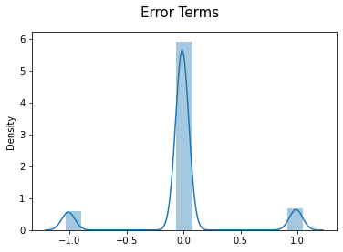

```python
fig = plt.figure()
sns.distplot(res, bins = 15)
fig.suptitle('Error Terms', fontsize = 15)                  # Plot heading
plt.show()
```

```python
X_test_sm = sm.add_constant(X_test)

# Predict the y values corresponding to X_test_sm
y_pred = lr.predict(X_test_sm)
```

```python
y_pred.head()
```

```
11845     2358.013430
3353      3093.013437
8863     77959.011071
23037     4774.013349
4364      2893.013698
dtype: float64
```

```python
from sklearn.metrics import mean_squared_error
from sklearn.metrics import r2_score
```

```python
#Returns the mean squared error; we'll take a square root
np.sqrt(mean_squared_error(y_test, y_pred))
r_squared = r2_score(y_test, y_pred)
r_squared
```

```
0.999999999992928
```

## Model 2: Logistic Regressionn

```python
df.revenue_to_cost_rate.describe()
```

```
count    24743.000000
mean         1.908928
std          0.497976
min          0.000000
25%          1.573688
50%          1.829897
75%          2.092941
max          4.358086
Name: revenue_to_cost_rate, dtype: float64
```

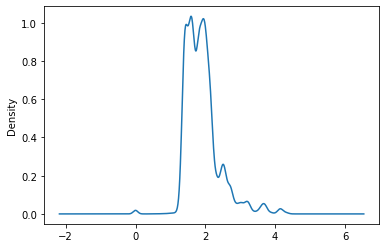

```python
df['revenue_to_cost_rate'].plot.kde()
```

Let us build a boolean value called 'profit_satisfied' with 'true' or 'false' values

Our threshold should be on the mean value here (1.9)

```python
df['profit_satisfied'] = np.where(df['revenue_to_cost_rate']>1.9, 1, 0)
```

```python
df.groupby('profit_satisfied')['profit_satisfied'].count()
```

```
profit_satisfied
0    13810
1    10933
Name: profit_satisfied, dtype: int64
```

#### Now the values are assigned, let us run a logistic regression to see if we can predict the sales satisfaction boolean

```python
X = df[['Revenue', 'Planned_revenue','Product_cost']]
y = df['profit_satisfied']
```

```python
X_train,X_test,y_train,y_test = train_test_split(X,y,test_size=0.25,random_state=0)
```

```python
from sklearn.linear_model import LogisticRegression
import seaborn as sn
from sklearn import metrics

logmodel = LogisticRegression()
logmodel.fit(X_train,y_train)

y_pred = logmodel.predict(X_test)
```

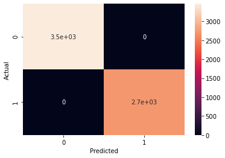

```python
confusion_matrix = pd.crosstab(y_test, y_pred, rownames=['Actual'], colnames=['Predicted'])
sn.heatmap(confusion_matrix, annot=True)
```

```python
print('Accuracy: ',metrics.accuracy_score(y_test, y_pred))
plt.show()
```

```
Accuracy:  1.0
```

### Model Summary

Accuracy of this logistic regression model is 100% meaning that `profit_satisfied` category completely depends on ['Revenue','Planned Revenue','Product Cost']

## Future Steps & Conclusions

- Too many missing values
- More features on the data like customer related info, months, day, seasonality information
- Breakdown of cost and sales into multiple factors (operational cost, labour cost and so on)
- With more transaction-level customer metrics, we can build recommendation systems

If we can gather these details, we can expand our analysis to different dimensions